# Visualisation, Plotting & Data Handling

EE1021 Programming for Engineers - Lecture 13

Basri Erdogan

# Visualisation and Plotting

## Basic Plotting I

- You can create a basic line graph in MATLAB using the function `plot`.
- `plot(y)` will plot your data (y) against an arbitrary (numbered) x-axis.
- `plot(x, y)` will plot your data (y) against the corresponding x-axis locations in x.
- If y is a matrix, the `plot` function will display all columns of y as separate lines.
- For data arranged in rows, use the apostrophe shortcut `'` to transpose the matrix.

## Basic Plotting II

- You can create a basic line graph with error bars using the function `errorbar`.
- `errorbar(x, y, SE)` will plot data with error bars whose length is specified by SE.
- Scatter plots can be created in MATLAB using the `scatter` function.
- The `scatter` function requires a minimum of two inputs (i.e. both x and y data).

## Plot Types Visual

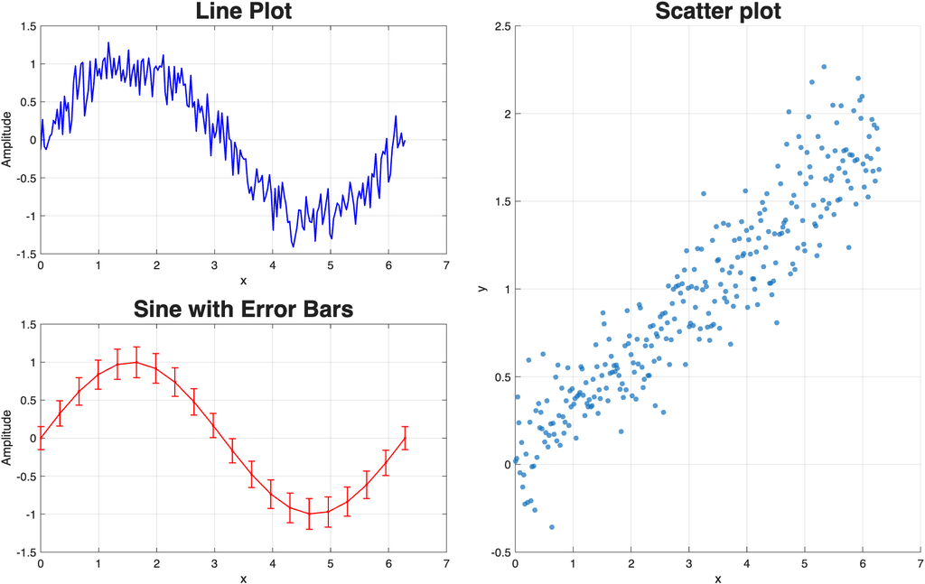

## Basic Figure Handling

- The `plot` function automatically generates a new figure window, if one is not open.
- The `plot` function automatically overwrites an existing figure window, if one is open.
- To open an additional figure window, use the `figure` command.
- To add lines to an existing figure, use the `hold on` / `hold off` commands.
- You can close figures individually with the `close` command.
- Note that this will close the most recently active figure.
- You can close all figures with the `close all` command.

## Axis Limits

- MATLAB automatically scales figure axes to accommodate the data being plotted.
- Axes limits can be manually controlled using `xlim([min max])` and `ylim([min max])`.
- The `axis` function can also be used adjust axes in several different ways.
- `axis tight` fits the axes limits to the data exactly.
- `axis square` makes the figure axes square, for display purposes.
- `axis off` removes the axes, labels and background, for display purposes.
- Each of these axis limit commands can be used on any MATLAB plot.

## Axis Limits Visual

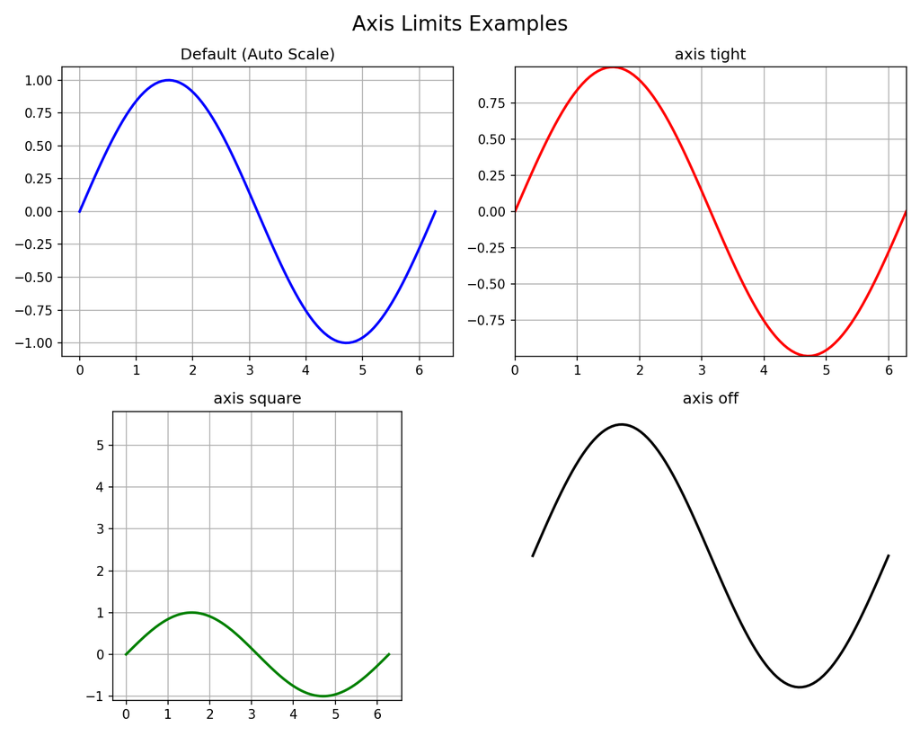

## Figure Text

- There are several functions for adding labels, titles and text to figures.
- Axes can be labelled using the functions `xlabel('string')` and `ylabel('string')`.
- Titles can be added to a figure using the function `title('string')`.
- Text can be added to a figure using the function `text(x_position, y_position, 'string')`.
- Text added by these functions can also be formatted directly from the command line.
  - This is achieved by passing additional inputs to the function.
  - For example: `title('string', 'FontSize', 24)` or `title('string', 'FontName', 'Times')`.

## Figure Text Visual

```matlab
xlabel('Time (s)', 'FontSize', 14)
ylabel('Amplitude (V)', 'FontSize', 14)

title('Damped Sine Wave Analysis', ...
      'FontSize', 24, ...
      'FontName', 'Serif')

text(2, 0.8, 'Peak Value', ...
     'FontSize', 16, ...
     'Color', 'red')

text(2, -0.5, 'y = sin(x) * e^{-0.1x}', ...
     'FontSize', 14, ...
     'FontAngle', 'italic', ...
     'BackgroundColor', 'white')
```

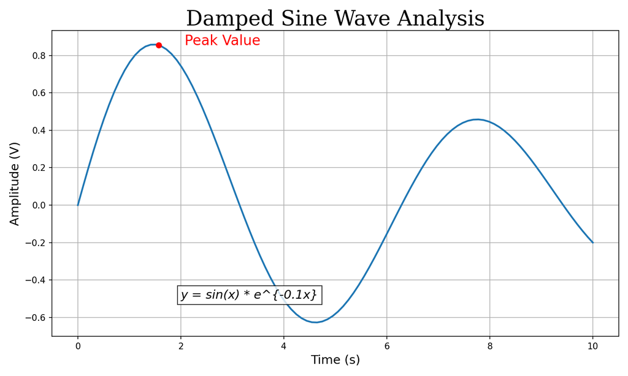

## Editing Figure Properties I

- There are two ways to edit the properties of a figure.
- The first is through the figure window toolbar, by clicking Edit -> Figure Properties…
- This brings up an additional panel at the bottom of the figure window.
- Clicking on various parts of the figure then allows you to edit properties directly.
- For example, click on or near the axes, and you can edit the labels, font and limits.
- Clicking on the plotted line allows you to edit the colour, line style and marker style.

## Figure Window Toolbar Visual

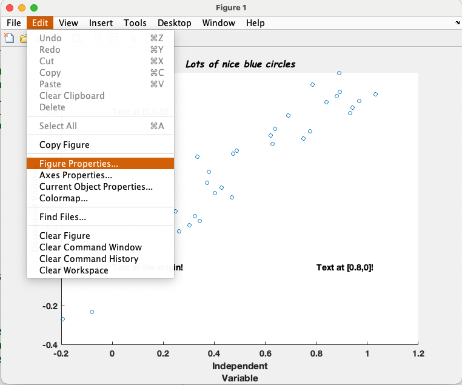

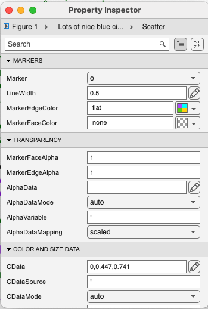

## Editing Figure Properties II

- The second way to edit a figure is directly from the command line.
- Basic properties can be defined when first creating the plot.
- These include `LineWidth`, `LineStyle`, and `Color` for lines…
- …and `Marker`, `MarkerEdgeColor`, `MarkerFaceColor` and `MarkerSize` for markers.
- For example: `plot(x, y, 'LineWidth', 3, 'Color', 'r', 'LineStyle', '--')`
- The colour, line and marker style alone can be defined in a single set of apostrophes.
- For example: `plot(x, y, 'r--*')`

## MATLAB Color, LineStyle, and Marker Codes

**Color**

- `b`: Blue (default)
- `g`: Green
- `r`: Red
- `k`: Black
- `y`: Yellow
- `w`: White
- `c`: Cyan
- `m`: Magenta

**LineStyle**

- `-`: Solid line (default)
- `--`: Dashed line
- `-.`: Dash-dot line
- `:`: Dotted line
- `none`: No line

**Marker**

- `o`: Circle
- `.`: Point
- `x`: Cross
- `+`: Plus sign
- `*`: Asterisk
- `s`: Square
- `d`: Diamond
- `v`/`^`: Triangles
- `p`: Pentagram
- `h`: Hexagram

## Editing Figure Properties III

- More complex properties can be adjusted using the `set` function.
- The general syntax for this is `set(FigureHandle, 'Property_Name', Value)`.
- For example: `set(gca, 'TickDir', 'out', 'Xscale', 'log')`.
- There are a number of different properties that can be changed in this way.
- These can be viewed by searching for ‘Axes Properties’ in MATLAB help.
- The ‘figure handle’ identifies the figure that we wish to edit.
- For now, we will use the shortcut `gca`, which specifies the ‘current’ figure.

## Editing Figure Properties Visual

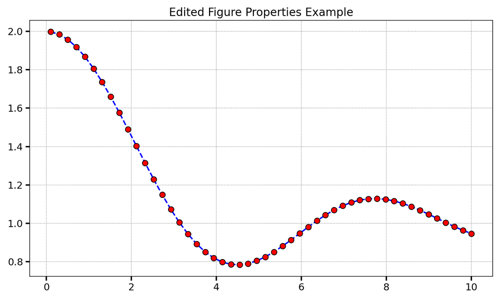

```matlab
% Define line properties during plot creation
plot(x, y, ...
    'LineWidth', 2, ...
    'LineStyle', '--', ...
    'Color', 'b', ...
    'Marker', 'o', ...
    'MarkerSize', 8, ...
    'MarkerFaceColor', 'r', ...
    'MarkerEdgeColor', 'k');

% Edit axes properties using 'set'
set(gca, ...
    'TickDir', 'out', ...
    'FontSize', 14, ...
    'XGrid', 'on', ...
    'YGrid', 'on');
```

## Subplots

- Several different panels can be plotted within a single figure using `subplot`.
- The syntax is: `subplot(Panel_Rows, Panel_Columns, Panels_to_be_used)`.
- Panels are numbered along each row.
- For example, `subplot(2,2,1)` sets up a 2 x 2 square of panels, and plots in the first.
- Plots can also be spread across multiple panels.

## Advanced Figure Handling

- When drawing subplots, figure handles can be used to control each panel separately.
- This means assigning a variable to each panel.
- This is achieved by providing the `subplot` function with an output variable.
- For example, `h1 = subplot(2,2,1)`.
- Properties of that specific panel can then be controlled using `set(h1, …)` etc.

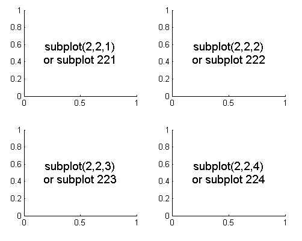

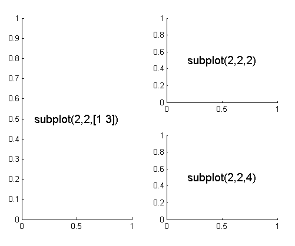

## Subplot Example Visual

[figure not shown]

```matlab
% Create a new figure
figure;

% First subplot: Sine wave
subplot(2, 2, 1);
plot(t, sin(t), 'b-');
title('Sine Wave');

% Second subplot: Scatter plot
subplot(2, 2, 2);
scatter(rand(1,20), rand(1,20), 'r');
title('Scatter Plot');

% Third subplot: Bar chart
subplot(2, 2, 3);
bar([10 25 15 30], 'g');
title('Bar Chart');

% Fourth subplot: Cosine wave
subplot(2, 2, 4);
plot(t, cos(t), 'k--');
title('Cosine Wave');
```

## Bar Charts

- Vertical and horizontal bar charts can be created using the `bar` and `barh` functions.
- Like plot, `bar(y)` plots the data in y on an arbitrary x-axis of 1 to length(y)…
- …while `bar(x, y)` plots the data in y at the x-axis positions defined in x.
- The width of the bars can be defined by a third input, i.e. `bar(x, y, width)`.
- Other properties can be defined using the `PropertyName`, Value syntax from above.
- For example: `bar(x, y, 'FaceColor', 'r', 'EdgeColor', 'k')`.
- A list of bar chart properties can be found by searching for ‘Barseries properties’.

## Bar Charts Visual

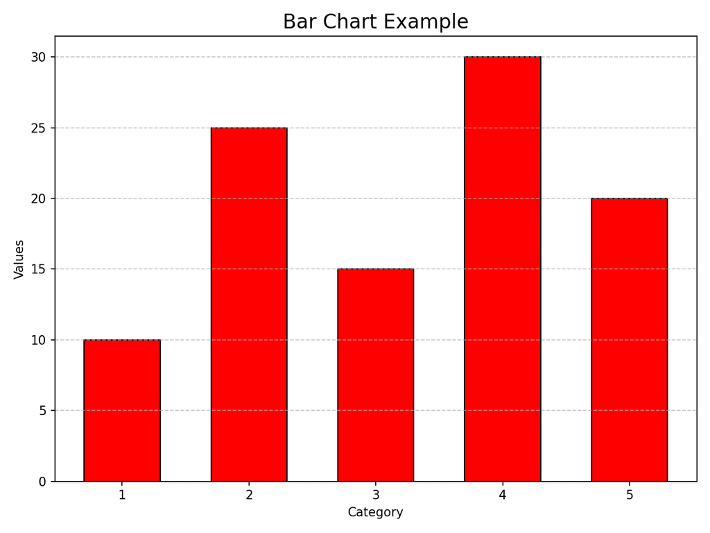

```matlab
x = [1, 2, 3, 4, 5];
y = [10, 25, 15, 30, 20];

% Create a bar chart with custom colors
bar(x, y, ...
    'FaceColor', 'r', ...
    'EdgeColor', 'k');

title('Bar Chart Example');
xlabel('Category');
ylabel('Values');
```

## Histograms

- Histograms can be created using the `hist` function.
- Providing a single input will plot a histogram with 10 evenly spaced bins, i.e. `hist(y)`.
- The second input can be used to define the centre of the x-axis bins, i.e. `hist(y,x)`.
- …or to define the total number of evenly spaced bins, i.e. `hist(y,n)`.
- Note that the syntax differs from `plot` – input the data first, x-axis positions second.

## Histograms Visual

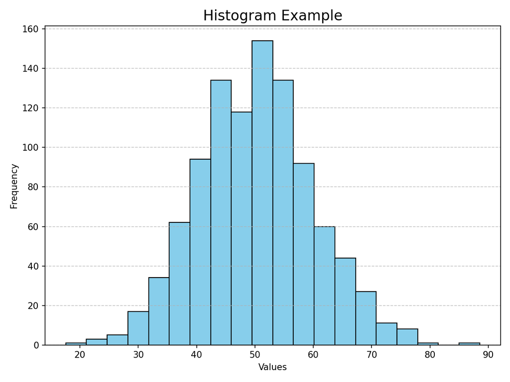

```matlab
% Generate random data
y = randn(1000, 1) * 10 + 50;

% Plot histogram with 20 bins
hist(y, 20);

% Customizing look (using bar properties for output of hist)
h = findobj(gca,'Type','patch');
set(h,'FaceColor','cyan','EdgeColor','k');

title('Histogram Example');
xlabel('Values');
ylabel('Frequency');
```

## Contour Plots

- Two dimensional plots can be created using `contourf`.
- There are several ways to provide data to this function:
  - `contourf(Z)`: Uses the column and row indices of Z as x and y coordinates.
  - `contourf(X, Y, Z)`: Uses X and Y matrices to define the coordinates for Z.
- **Data Formats**:
  - `X` and `Y`: Usually generated using `meshgrid`. `X` varies across columns, `Y` varies down rows.
  - `Z`: A matrix of the same size where `Z(i,j)` is the height/color at `(X(i,j), Y(i,j))`.
- The `contourf` function also allows you to specify how many z gradations are plotted.
  - For example, `contourf(x, y, c, n)`.

## Contour Plots Visual

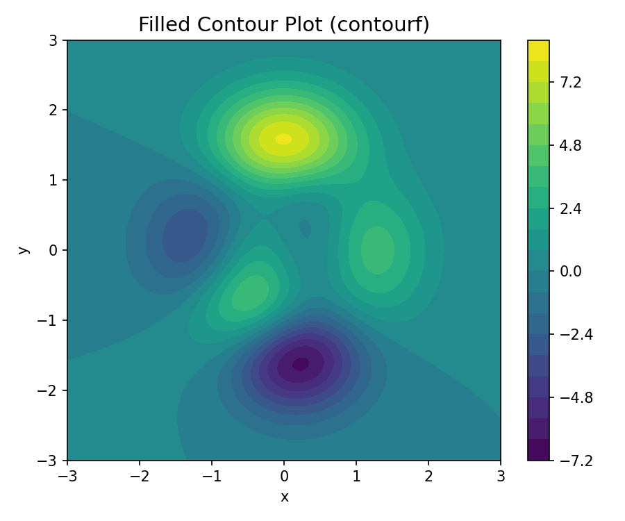

```matlab
% Create coordinate grid
x = linspace(-3, 3, 100);
y = linspace(-3, 3, 100);
[X, Y] = meshgrid(x, y);

% Define function Z on grid
Z = 3*(1-X).^2.*exp(-(X.^2) - (Y+1).^2) ...
   - 10*(X/5 - X.^3 - Y.^5).*exp(-X.^2-Y.^2) ...
   - 1/3*exp(-(X+1).^2 - Y.^2);

% Plot filled contour with 20 levels
contourf(X, Y, Z, 20);
colorbar;
title('Filled Contour Plot');
xlabel('x'); ylabel('y');
```

## Image Plots

- Image plots can be created using `imagesc`.
- Like contour plots, you can pass a single matrix or x/y coordinates:
  - `imagesc(C)` or `imagesc(x, y, C)`.
- **Note**: The `imagesc` function automatically inverts the y-axis (image coordinate system).
- This can be corrected to standard Cartesian coordinates using:
  - `set(gca, 'Ydir', 'normal')` or `axis xy`.

## Image Plots Visual

[figure not shown]

```matlab
% Using the same Z data as before

% Plot as image
% imagesc scales colors to data range
imagesc(x, y, Z);
colorbar;

% Invert Y-axis to match
% standard plot orientation
set(gca, 'Ydir', 'normal');

title('Image Plot (imagesc)');
xlabel('x'); ylabel('y');
```

## Other Useful Plotting Functions

- There are many different plotting functions within MATLAB.
- Each of these can be controlled using the general syntax discussed above.
- Information on the specific syntax used for each function can be found in the ‘Help’ file.
- Some examples include:
  - `plotyy`: allows you to plot multiple lines on one figure with different y-axes.
  - `pie`: allows you to plot a pie chart (with one emerging segment!).
  - `loglog`, `semilogx`, `semilogy`: allows you plot one or more logarithmic axes.
  - `surf`: allows you to plot a 3D surface (like the MATLAB logo!).

## Other Useful Plotting Tools

- There are several buttons at the top of the Figure window that may be useful.
- The ‘Data Cursor’ returns the x and y co-ordinates of any point clicked on.
- The ‘Insert Legend’ button inserts an editable legend to annotate your figure.
- The ‘Insert Colorbar’ button adds a ‘colorbar’ (i.e. z-axis scale) to your figure.
- There are also buttons for zooming in and out of your figure.
- Finally, it is important to note that you can save figures in several formats.
- These include `*.bmp`, `*.jpg`, various Adobe Illustrator formats etc.
- Figures saved in the native MATLAB `*.fig` format can be re-opened and edited.

# Importing and Handling Data

## Introduction: MATLAB vs Python

- You are likely familiar with **Python** and **NumPy**.
- **MATLAB** is very similar, but with some key differences:
  - **Everything is a Matrix**: Like `numpy.array`, but by default.
  - **Indexing**: MATLAB uses **1-based indexing** `A(1)`, while Python uses 0-based `A[0]`.
  - **Slicing**: MATLAB uses `1:10` (inclusive), Python uses `0:10` (exclusive of end).
- **Goal**: Import data, process it (like pandas/numpy), and visualize it.

## Importing Data: The Modern Way

- Forget `dlmread` or `csvread`. Use modern functions:
- **`readmatrix`**: Best for purely numerical data (like `numpy.loadtxt`).
  - `data = readmatrix('scope_trace.csv');`
- **`readtable`**: Best for mixed data (like `pandas.read_csv`).
  - `T = readtable('experiment_log.csv');`
  - Access columns by name: `T.Voltage` (like `df['Voltage']`).

## Data Structures: Structs vs Dicts

- In Python, you use **Dictionaries** to group named data:
  - `d = {'volts': [1, 2], 'unit': 'V'}`
- In MATLAB, use **Structures** (`struct`):
  - `data.volts = [1 2];`
  - `data.unit = 'V';`
- Accessed using **dot notation**: `value = data.volts(1);`

## Data Structures: Cell Arrays vs Lists

- In Python, **Lists** can hold anything: `L = [1, 'text', np.array([1])]`.
- In MATLAB, standard arrays must be homogeneous (all numbers).
- Use **Cell Arrays** (curly braces `{}`) to store mixed types:
  - `C = {1, 'text', [1 2 3]};`
  - Access content with curly braces: `val = C{1};`

## Real-World Example: Oscilloscope Data

- **Scenario**: You saved a CSV file from a Tektronix scope (`tek0001.csv`).
- **File Format**: Header rows, then Time (Col 1) and Voltage (Col 2).

```matlab
% 1. Import Data (skipping header automatically)
data = readmatrix('tek0001.csv');

% 2. Extract Columns (NumPy style slicing)
t = data(:, 1); % Time vector
v = data(:, 2); % Voltage vector

% 3. Analyze
v_peak = max(v);
fprintf('Peak Voltage: %.2f V\n', v_peak);

% 4. Visualize
plot(t, v);
xlabel('Time (s)'); ylabel('Voltage (V)');
title('Oscilloscope Capture');
grid on;
```

# Programming Guidelines For Beginners

## Overview

- Procedural programs (Matlab scripts) are like cooking recipes.
- Even the most complex recipes are composed of elementary steps.
- You can make your life easier by following some simple guidelines.

**Outline:**

1. Visual aspects / Presentation
2. Organizing your code
3. Memory and Performance

## Basic Visual Aspects

- Use meaningful file/variable names (within reason).
- Use spacing and white-space to write clean and easy to parse code.
- Alignment (within reason).
- Indentation – Matlab will allow you to break the conventions – Don’t!
- Take advantage of Matlab editor features like cells and code-folding.

## Developing and Organizing Your Code I

- Assign variables early, make your code easily extendable/adaptable.
- Go from simple to complex: If you are faced with a complex issue, develop a toy model first.
- Modular programming: create functions when possible.
  - cleaning up your code
  - creating reusable scripts/functions
  - separating conceptually distinct problems
- Backup your code, with a meaningful naming conventions (insurance against computer failure).
- Backup working code before trying out new things (insurance against stupidity).

## Developing and Organizing Your Code II

- Make extensive use of comments!
  - Making your code understandable to others that might use it.
  - And to your future self!
- Matlab does not necessarily return errors when it does not do what you intended.
  - These are usually the most insidious bugs.
  - Don’t have faith! Always test your code with simple examples.

## Memory and Performance

- Optimizing your code is important for large projects. A very wide topic.
- But even for smaller projects a few basic guidelines should be followed.
- Pre-assign arrays and don’t let them grow inside of loops.
- Avoid loops when possible (are slow), favor matrix algebra.
- Favor logical operators over the built-in functions “find” and “nonzeros”.
- Consider using sparse matrices (but sparse indexing is slow).